# Random Forests

29 octubre 2019

# 1 Lectura de datos

```r
library(tree)
d = read.table('datos/coches.txt',header=T)
d = na.omit(d)
d$origen = factor(d$origen, labels = c("USA","Europa","Japon"))
```

# 2 Training set *vs* Test set

Dividimos los datos en dos partes, una para entrenar el modelo y otra para calcular el error de predicción con datos diferentes de los utilizados para entrenar:

```r
set.seed(321)
ndat = nrow(d)
pos_train = sample(1:ndat,ndat/2) # la mitad de los datos para entranamiento
datos_train = d[pos_train,] # trainning set
datos_test = d[-pos_train,] # test set
```

# 3 Random Forest

- Se remuestrea con reemplazamiento *B* veces.
- Se estima un arbol para cada muestra, $f_b(x)$. Pero cada vez que se divide un nodo en cada arbol, se seleccionan aleatoriamente *m* regresores de los *p* disponibles. Por defecto, R considera $p/3$. En el caso de que m = p se denomina **BAGGING**.
- Se calcula la predicción proporcionada por cada árbol, $\hat f_b(x)$.
- Se promedian las predicciones.

$$\hat f_{RF} = \frac{1}{B}\sum_{b=1}^B \hat f_b(x)$$

- La gran ventaja de random forest frente a bagging es que funciona muy bien con datos que tienen variables correlacionadas.

## 3.1 mtry = 7 (**BAGGING**)

```r
library(randomForest)
# numero total de regresores: 7
rf1 = randomForest(consumo ~ ., data = datos_train, mtry = 7, ntree = 500)
```

Error del modelo:

```r
yp_train_rf1 <- predict(rf1, newdata = datos_train)
y_train = datos_train$consumo
# error cuadratico medio en los datos de training
( MSE_train_rf1 = mean((y_train - yp_train_rf1)^2) )
```

```
## [1] 0.3210797
```

Error de predicción:

```r
# prediccion del consumo con los datos test
yp_test_rf1 = predict(rf1, newdata = datos_test)

# error del test set
y_test = datos_test$consumo
(MSE_test_rf1 = mean((y_test - yp_test_rf1)^2))
```

```
## [1] 2.185575
```

## 3.2 mtry = 3

```r
rf2 = randomForest(consumo ~ ., data = datos_train, mtry = 3, ntree = 500)
```

Error del modelo:

```r
yp_train_rf2 <- predict(rf2, newdata = datos_train)
# error cuadratico medio en los datos de training
( MSE_train_rf2 = mean((y_train - yp_train_rf2)^2) )
```

```
## [1] 0.3634849
```

Error de predicción:

```r
# prediccion del consumo con los datos test
yp_test_rf2 = predict(rf2, newdata = datos_test)
# error del test set
(MSE_test_rf2 = mean((y_test - yp_test_rf2)^2))
```

```
## [1] 2.19534
```

## 3.3 mtry = 5

```r
rf3 = randomForest(consumo ~ ., data = datos_train, mtry = 5, ntree = 500)
```

Error del modelo:

```r
yp_train_rf3 <- predict(rf3, newdata = datos_train)
# error cuadratico medio en los datos de training
( MSE_train_rf3 = mean((y_train - yp_train_rf3)^2) )
```

```
## [1] 0.3326407
```

Error de predicción:

```r
# prediccion del consumo con los datos test
yp_test_rf3 = predict(rf3, newdata = datos_test)

# error del test set
(MSE_test_rf3 = mean((y_test - yp_test_rf3)^2))
```

```
## [1] 2.159857
```

# 4 Importancia de variables

```r
rf4 = randomForest(consumo ~ ., data = datos_train, mtry = 5, ntree = 500, importance = T)
```

```r
importance(rf4)
```

```
##            %IncMSE IncNodePurity
## cc        23.34714   1144.091032
## cv        13.81813    350.400180
## peso      22.20863    816.553365
## acel       7.52297     36.763574
## ano       40.21519    175.723637
## origen     3.94728      6.947013
## cilindros 10.31921    211.574000
```

- %IncMSE: descenso de la calidad de las predicciones realizadas en los datos *out of samples* cuando los valores de una variable dada se permutan aleatoriamente (sería como quitarla del modelo).
- IncNodePurity: suma del descenso acumulado del RSS al partir por dicha variable.

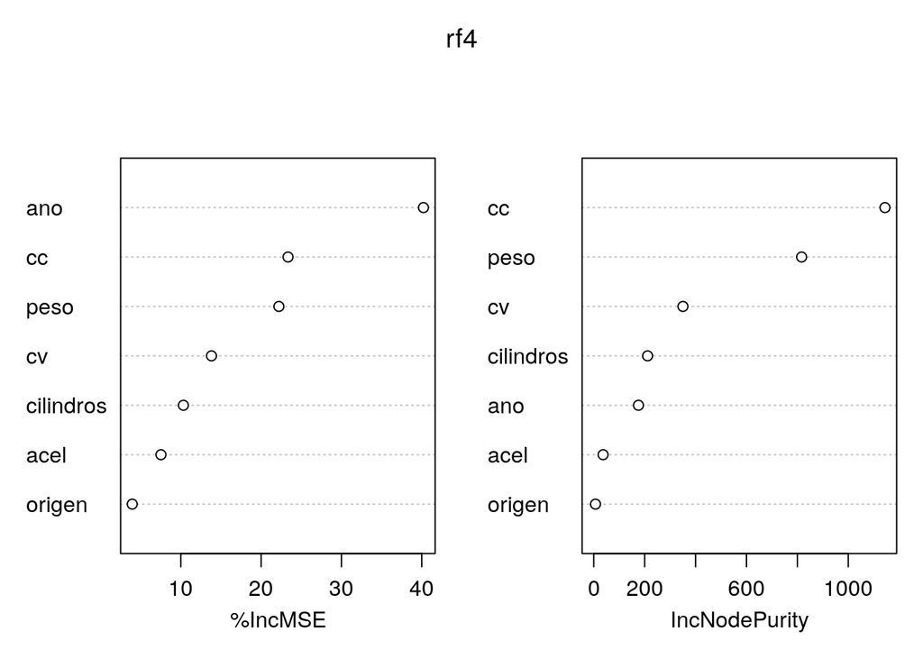

```r
varImpPlot(rf4)
```